## Background

We initialize a population of size one million using the ARI, and age structure that mimics South Africa. We then generate new case of disease over a one year period and explore the role of reinfection in generating new cases of disease. We simulate populations with prevalence ranging from 100/100k to 1000/100k.

We consider two scenarios:

1. Homogenous risk of TB infection in the population
2. Heterogenous risk: 20% of the population has an ARI that is 6 times greater than the low risk population.

The ARI is challenging to estimate. We use two approaches:

1. Dodd et al demonstrate a relationship between TB prevalence and the ARI. We leverage this to determine the overall ARI.
2. We assume that the duration of disease is two years, as Styblo, and therefore prevalence must be twice incidence. In this case, we do parameter sweeps to determine the ARI that meets this condition for each prevalence scenario.

We also use the correction in these calculations that true prevalence should be 1.66 times reported to account for smear negative TB.

We keep track of repeat infection events and, following Ackley et al and Reichler, we allow there to initially be a protective effect of reinfection, but that this gradually wanes with an increasing number of infections. Following is a depiction of this assumption:

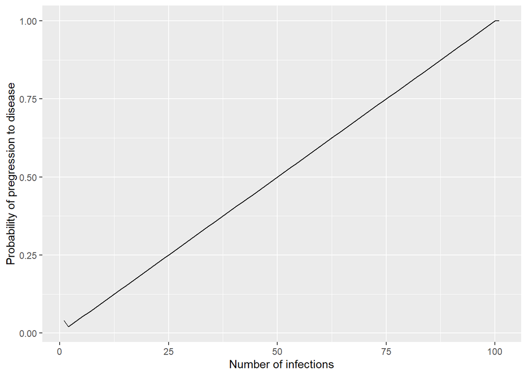

## Simulation scenarios

We run the simulation with four total scenarios: two ARI scenarios and two mixing scenarios.

ARI scenarios:

-Dodd et al ARIs (based on TB prevalence)

-ARIs derived assuming two year duration

Mixing scenarios:

-All population subject to the same risk of infection

-20% of the population is in a high risk category with 6 times the risk of infection as the remaining 80% of the population.

Following are these parameter assumptions:

[output not shown]

## Initializing the population

We first determine the number of infections that individuals have at the start of the simulation. We show this for all four scenarios.

### Dodd, Homogeneous risk

This block of results uses the Dodd et al ARIs (determined from prevalence and using data from uninfected children) with the assumption of homogeneous risk of infection in the population.

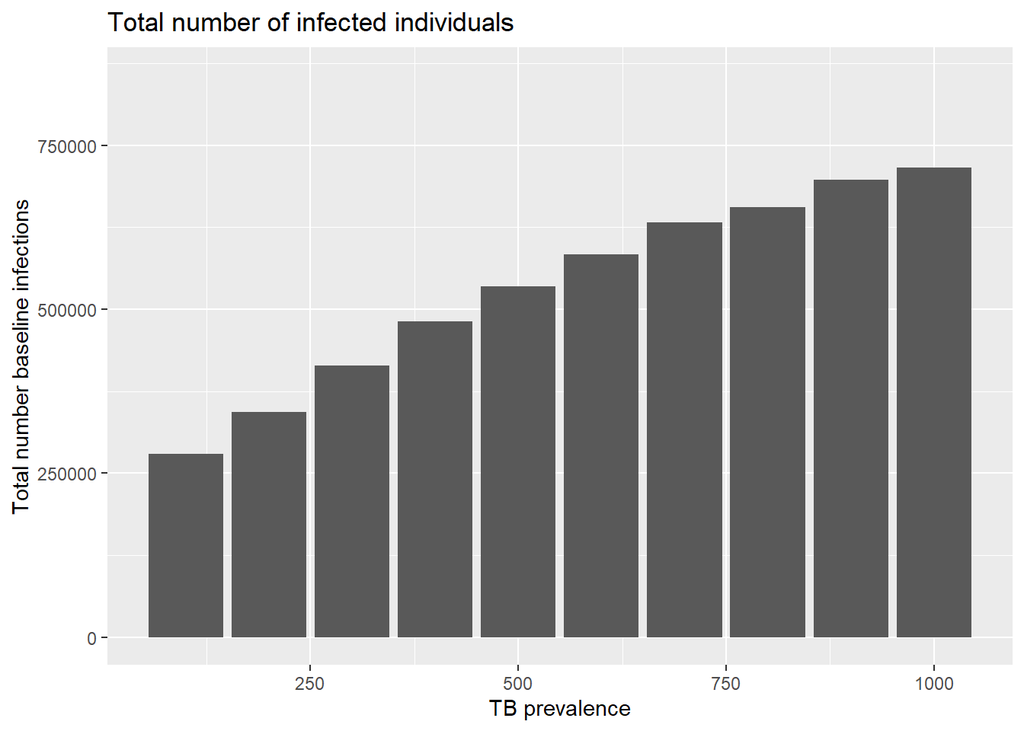

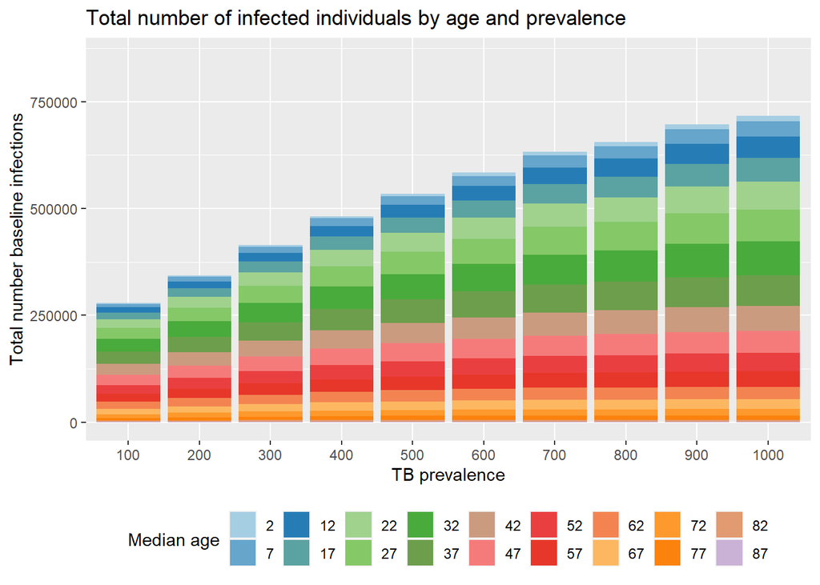

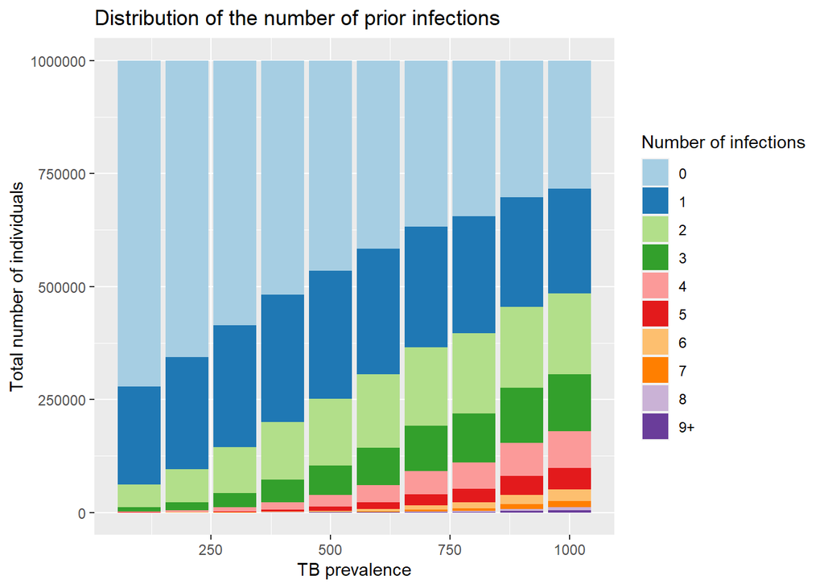

We focus in on those with at least six prior infections in this plot.

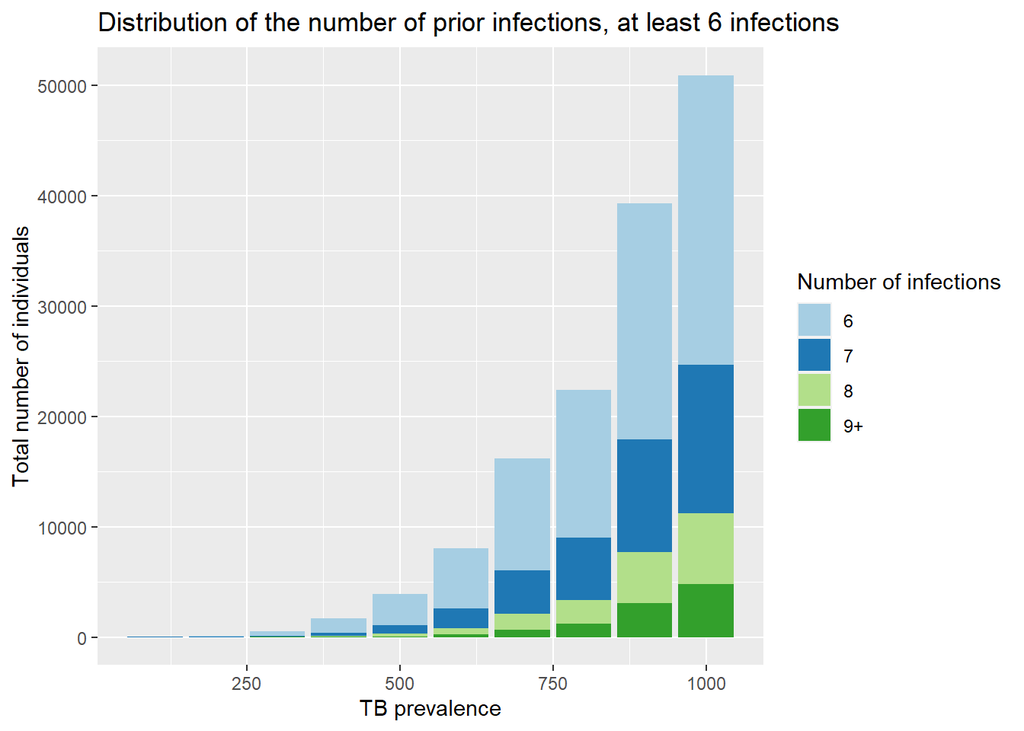

Finally, we show the prevalence of LTBI by age and TB disease prevalence. This can be compared to the Dodd et al data.

Prevalence of LTBI by age and TB prevalence

|  | Prev100 | Prev200 | Prev300 | Prev400 | Prev500 | Prev600 | Prev700 | Prev800 | Prev900 | Prev1000 |
| --- | --- | --- | --- | --- | --- | --- | --- | --- | --- | --- |
| 0-4 | 0.02 | 0.03 | 0.04 | 0.05 | 0.06 | 0.08 | 0.09 | 0.10 | 0.11 | 0.12 |
| 5-9 | 0.08 | 0.11 | 0.14 | 0.17 | 0.21 | 0.24 | 0.28 | 0.30 | 0.34 | 0.37 |
| 10-14 | 0.14 | 0.18 | 0.23 | 0.28 | 0.33 | 0.37 | 0.43 | 0.46 | 0.51 | 0.54 |
| 15-19 | 0.19 | 0.24 | 0.30 | 0.37 | 0.43 | 0.48 | 0.55 | 0.58 | 0.64 | 0.67 |
| 20-24 | 0.24 | 0.30 | 0.37 | 0.45 | 0.51 | 0.58 | 0.64 | 0.67 | 0.73 | 0.76 |
| 25-29 | 0.28 | 0.35 | 0.44 | 0.52 | 0.59 | 0.65 | 0.72 | 0.75 | 0.80 | 0.83 |
| 30-34 | 0.33 | 0.40 | 0.49 | 0.58 | 0.65 | 0.71 | 0.77 | 0.80 | 0.85 | 0.88 |
| 35-39 | 0.37 | 0.45 | 0.55 | 0.63 | 0.70 | 0.76 | 0.82 | 0.85 | 0.89 | 0.91 |
| 40-44 | 0.40 | 0.49 | 0.59 | 0.68 | 0.75 | 0.81 | 0.86 | 0.88 | 0.92 | 0.94 |
| 45-49 | 0.44 | 0.53 | 0.63 | 0.72 | 0.79 | 0.84 | 0.89 | 0.91 | 0.94 | 0.95 |
| 50-54 | 0.47 | 0.57 | 0.67 | 0.76 | 0.82 | 0.87 | 0.91 | 0.93 | 0.96 | 0.97 |
| 55-59 | 0.50 | 0.60 | 0.70 | 0.79 | 0.85 | 0.89 | 0.93 | 0.95 | 0.97 | 0.98 |
| 60-64 | 0.53 | 0.63 | 0.73 | 0.81 | 0.87 | 0.91 | 0.94 | 0.96 | 0.98 | 0.98 |
| 65=-69 | 0.56 | 0.66 | 0.76 | 0.84 | 0.89 | 0.93 | 0.96 | 0.97 | 0.98 | 0.99 |
| 70-74 | 0.59 | 0.69 | 0.78 | 0.86 | 0.91 | 0.94 | 0.97 | 0.97 | 0.99 | 0.99 |
| 75-79 | 0.61 | 0.71 | 0.81 | 0.88 | 0.92 | 0.95 | 0.97 | 0.98 | 0.99 | 0.99 |
| 80-84 | 0.64 | 0.74 | 0.83 | 0.89 | 0.93 | 0.96 | 0.98 | 0.98 | 0.99 | 1.00 |
| 85+ | 0.66 | 0.76 | 0.84 | 0.91 | 0.94 | 0.97 | 0.98 | 0.99 | 0.99 | 1.00 |

### Dodd, Heterogeneous risk

This section shows results using the Dodd ARIs (derived from prevalence data and using studies on unifected children). Here we assume that 20% of the population are in a high risk category and have an ARI that is 6 times higher than the remaining 80% of the population.

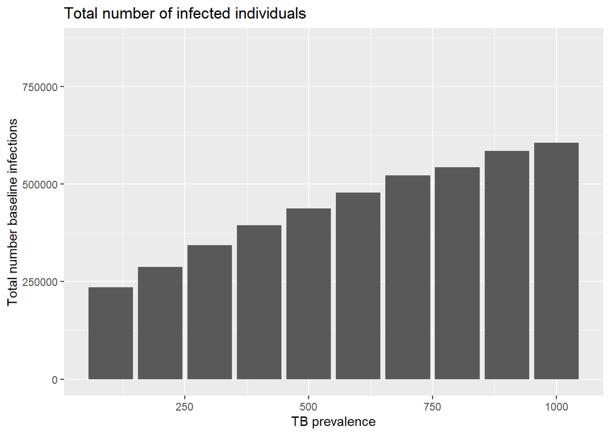

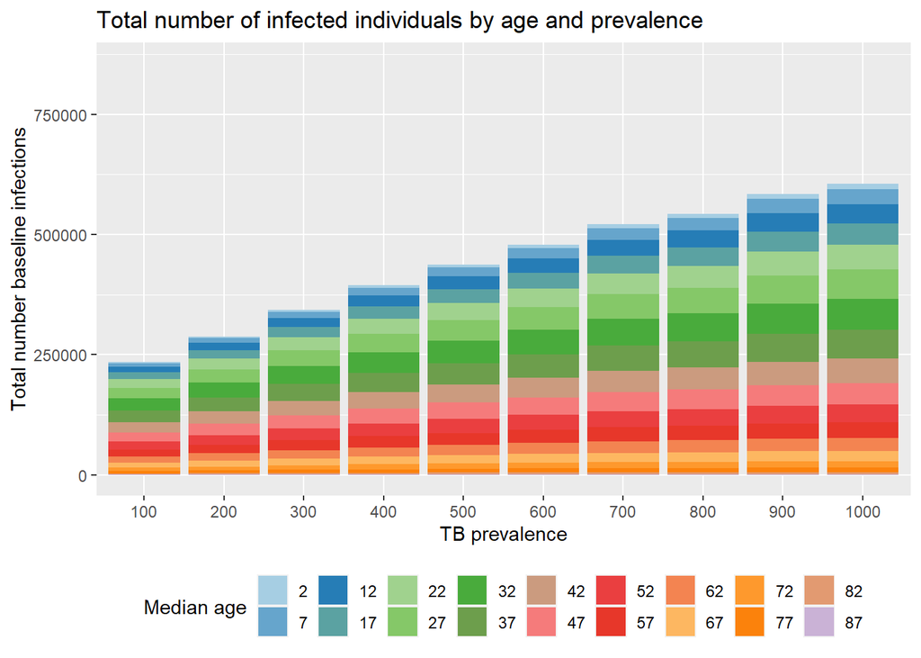

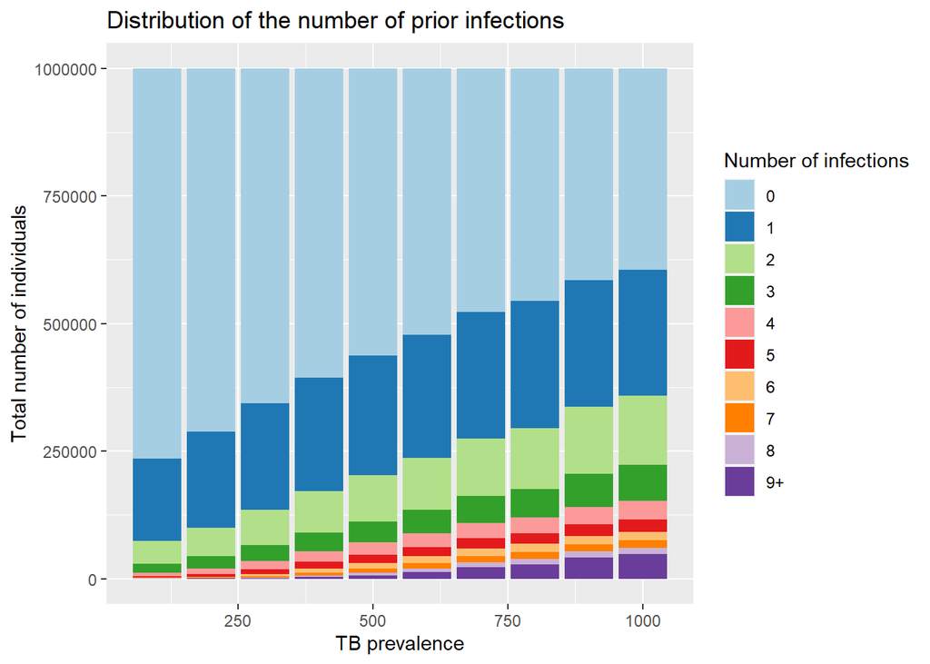

We focus in on those with at least six prior infections in this plot.

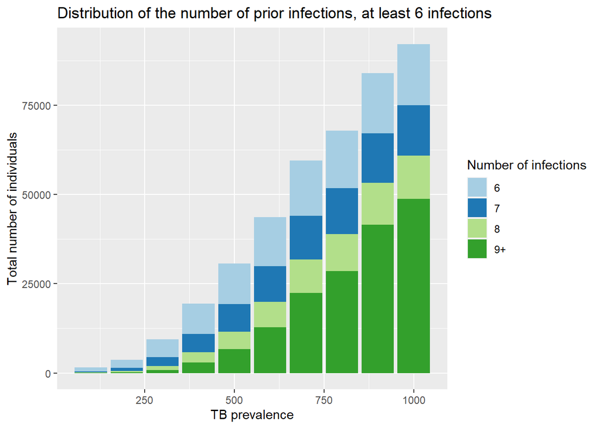

We show the prevalence of LTBI by age and TB disease prevlance. This can be compared to the Dodd et al data.

Prevalence of LTBI by age and TB prevalence

|  | Prev100 | Prev200 | Prev300 | Prev400 | Prev500 | Prev600 | Prev700 | Prev800 | Prev900 | Prev1000 |
| --- | --- | --- | --- | --- | --- | --- | --- | --- | --- | --- |
| 0-4 | 0.02 | 0.03 | 0.04 | 0.05 | 0.06 | 0.07 | 0.09 | 0.09 | 0.11 | 0.12 |
| 5-9 | 0.08 | 0.10 | 0.13 | 0.16 | 0.19 | 0.21 | 0.25 | 0.26 | 0.29 | 0.31 |
| 10-14 | 0.13 | 0.16 | 0.20 | 0.25 | 0.28 | 0.32 | 0.36 | 0.38 | 0.42 | 0.44 |
| 15-19 | 0.17 | 0.22 | 0.27 | 0.32 | 0.36 | 0.40 | 0.44 | 0.47 | 0.51 | 0.53 |
| 20-24 | 0.21 | 0.26 | 0.32 | 0.37 | 0.42 | 0.46 | 0.51 | 0.54 | 0.58 | 0.61 |
| 25-29 | 0.25 | 0.30 | 0.37 | 0.42 | 0.47 | 0.52 | 0.57 | 0.59 | 0.64 | 0.67 |
| 30-34 | 0.28 | 0.34 | 0.41 | 0.47 | 0.52 | 0.57 | 0.62 | 0.64 | 0.69 | 0.72 |
| 35-39 | 0.31 | 0.37 | 0.44 | 0.51 | 0.56 | 0.61 | 0.66 | 0.69 | 0.74 | 0.76 |
| 40-44 | 0.33 | 0.40 | 0.48 | 0.54 | 0.60 | 0.65 | 0.70 | 0.72 | 0.77 | 0.80 |
| 45-49 | 0.36 | 0.43 | 0.51 | 0.57 | 0.63 | 0.68 | 0.73 | 0.76 | 0.80 | 0.83 |
| 50-54 | 0.38 | 0.46 | 0.54 | 0.60 | 0.66 | 0.71 | 0.76 | 0.79 | 0.83 | 0.85 |
| 55-59 | 0.40 | 0.48 | 0.56 | 0.63 | 0.69 | 0.74 | 0.79 | 0.81 | 0.86 | 0.88 |
| 60-64 | 0.42 | 0.51 | 0.59 | 0.65 | 0.71 | 0.76 | 0.81 | 0.83 | 0.88 | 0.89 |
| 65=-69 | 0.44 | 0.53 | 0.61 | 0.68 | 0.73 | 0.78 | 0.83 | 0.85 | 0.89 | 0.91 |
| 70-74 | 0.46 | 0.55 | 0.63 | 0.70 | 0.75 | 0.80 | 0.85 | 0.87 | 0.91 | 0.92 |
| 75-79 | 0.48 | 0.57 | 0.65 | 0.72 | 0.77 | 0.82 | 0.87 | 0.89 | 0.92 | 0.93 |
| 80-84 | 0.49 | 0.58 | 0.67 | 0.74 | 0.79 | 0.84 | 0.88 | 0.90 | 0.93 | 0.94 |
| 85+ | 0.51 | 0.60 | 0.69 | 0.75 | 0.81 | 0.85 | 0.89 | 0.91 | 0.94 | 0.95 |

We also show the total number of infections and total number of times individuals have been infected by risk category.

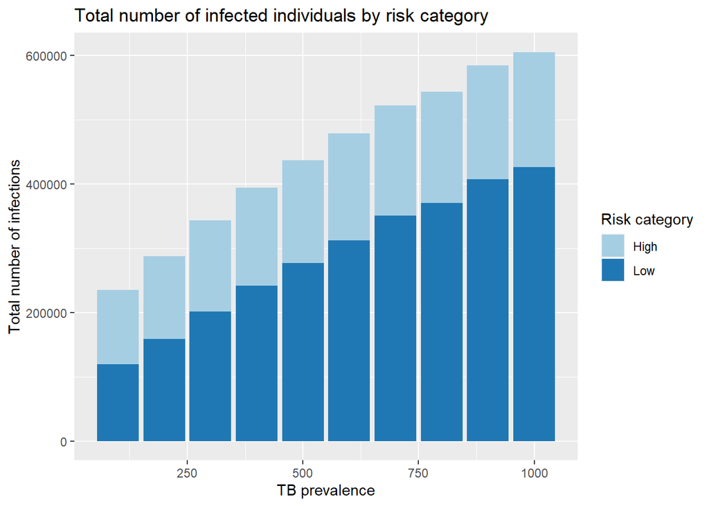

We can also consider the number of infections individuals have by prevalence and risk category.

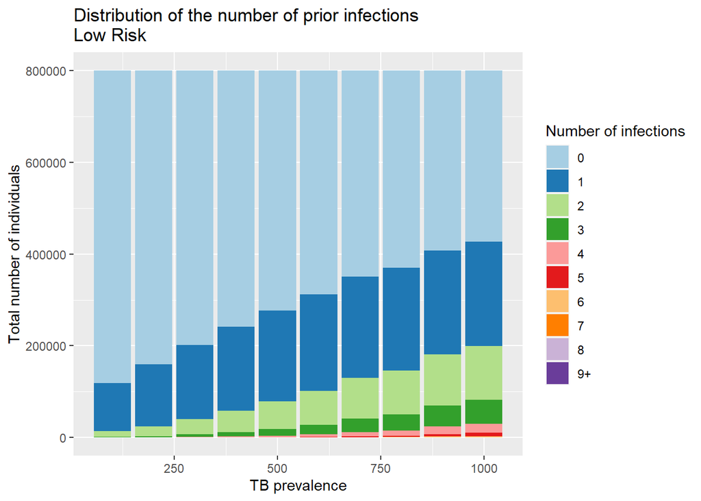

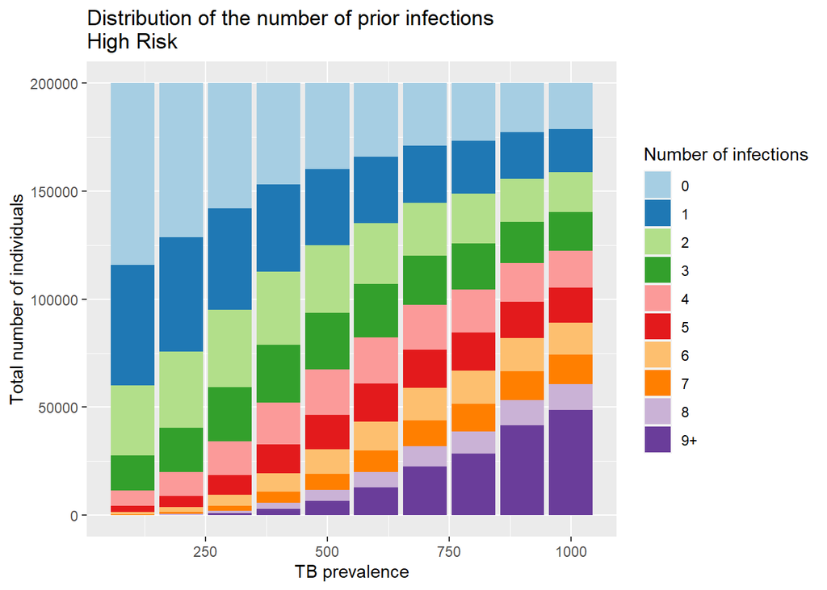

### Parameter sweep, Homogeneous risk

This block of results uses the parameter sweep determined ARI (determined assuming a two duration such that prevalence=2*incidence) with the assumption of homogeneous risk of infection in the population.

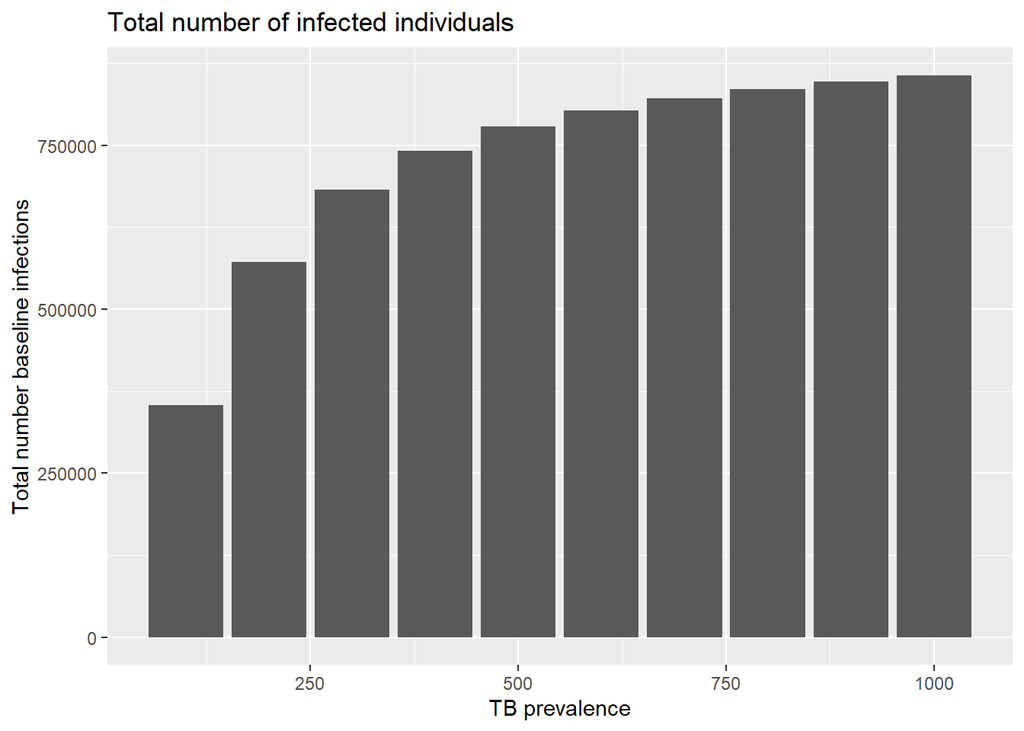

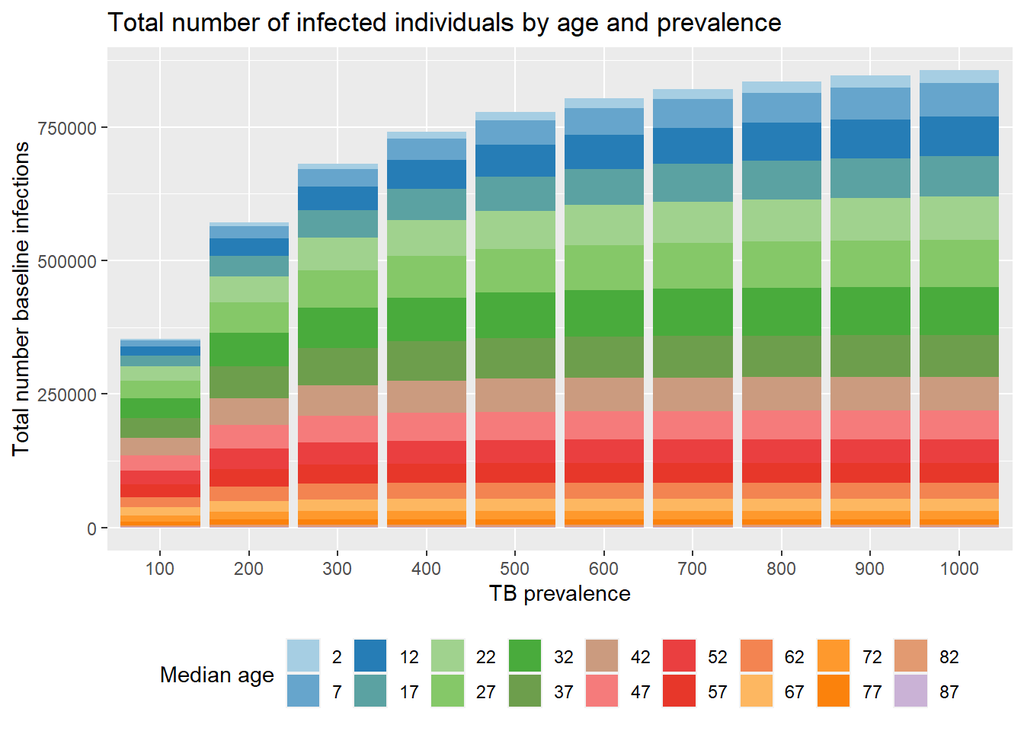

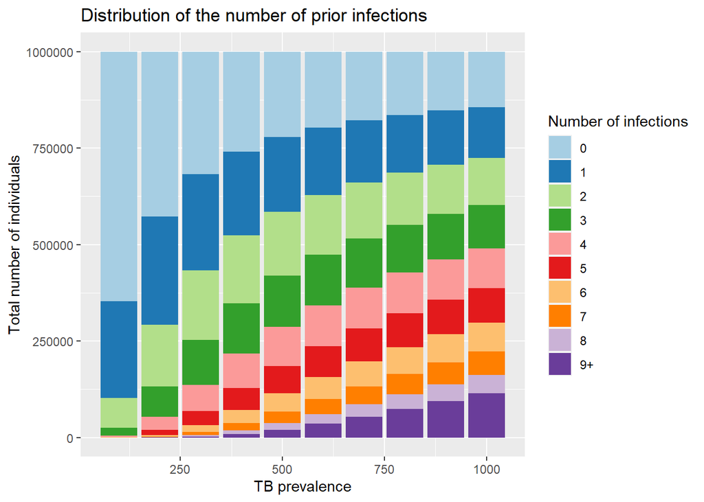

We focus in on those with at least six prior infections in this plot.

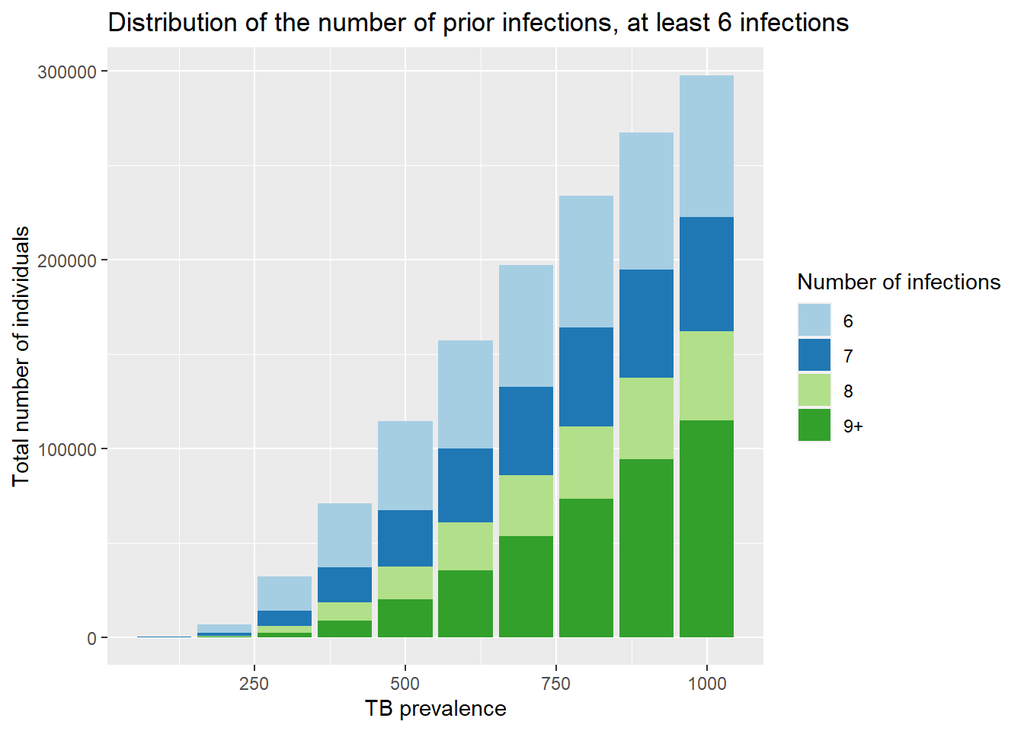

Finally, we show the prevalence of LTBI by age and TB disease prevalence. This can be compared to the Dodd et al data.

Prevalence of LTBI by age and TB prevalence

|  | Prev100 | Prev200 | Prev300 | Prev400 | Prev500 | Prev600 | Prev700 | Prev800 | Prev900 | Prev1000 |
| --- | --- | --- | --- | --- | --- | --- | --- | --- | --- | --- |
| 0-4 | 0.03 | 0.07 | 0.11 | 0.14 | 0.16 | 0.18 | 0.20 | 0.22 | 0.23 | 0.25 |
| 5-9 | 0.11 | 0.23 | 0.33 | 0.40 | 0.46 | 0.50 | 0.54 | 0.57 | 0.60 | 0.63 |
| 10-14 | 0.18 | 0.36 | 0.49 | 0.58 | 0.65 | 0.70 | 0.74 | 0.77 | 0.79 | 0.82 |
| 15-19 | 0.25 | 0.47 | 0.62 | 0.71 | 0.77 | 0.82 | 0.85 | 0.87 | 0.89 | 0.91 |
| 20-24 | 0.31 | 0.56 | 0.71 | 0.80 | 0.85 | 0.89 | 0.91 | 0.93 | 0.94 | 0.96 |
| 25-29 | 0.37 | 0.64 | 0.78 | 0.86 | 0.90 | 0.93 | 0.95 | 0.96 | 0.97 | 0.98 |
| 30-34 | 0.42 | 0.70 | 0.84 | 0.90 | 0.94 | 0.96 | 0.97 | 0.98 | 0.99 | 0.99 |
| 35-39 | 0.46 | 0.75 | 0.88 | 0.93 | 0.96 | 0.98 | 0.98 | 0.99 | 0.99 | 0.99 |
| 40-44 | 0.51 | 0.79 | 0.91 | 0.95 | 0.97 | 0.98 | 0.99 | 0.99 | 1.00 | 1.00 |
| 45-49 | 0.55 | 0.83 | 0.93 | 0.97 | 0.98 | 0.99 | 0.99 | 1.00 | 1.00 | 1.00 |
| 50-54 | 0.58 | 0.86 | 0.95 | 0.98 | 0.99 | 0.99 | 1.00 | 1.00 | 1.00 | 1.00 |
| 55-59 | 0.62 | 0.88 | 0.96 | 0.98 | 0.99 | 1.00 | 1.00 | 1.00 | 1.00 | 1.00 |
| 60-64 | 0.65 | 0.90 | 0.97 | 0.99 | 1.00 | 1.00 | 1.00 | 1.00 | 1.00 | 1.00 |
| 65=-69 | 0.68 | 0.92 | 0.98 | 0.99 | 1.00 | 1.00 | 1.00 | 1.00 | 1.00 | 1.00 |
| 70-74 | 0.70 | 0.93 | 0.98 | 0.99 | 1.00 | 1.00 | 1.00 | 1.00 | 1.00 | 1.00 |
| 75-79 | 0.73 | 0.94 | 0.99 | 1.00 | 1.00 | 1.00 | 1.00 | 1.00 | 1.00 | 1.00 |
| 80-84 | 0.75 | 0.95 | 0.99 | 1.00 | 1.00 | 1.00 | 1.00 | 1.00 | 1.00 | 1.00 |
| 85+ | 0.77 | 0.96 | 0.99 | 1.00 | 1.00 | 1.00 | 1.00 | 1.00 | 1.00 | 1.00 |

### Parameter sweep, Heterogeneous risk

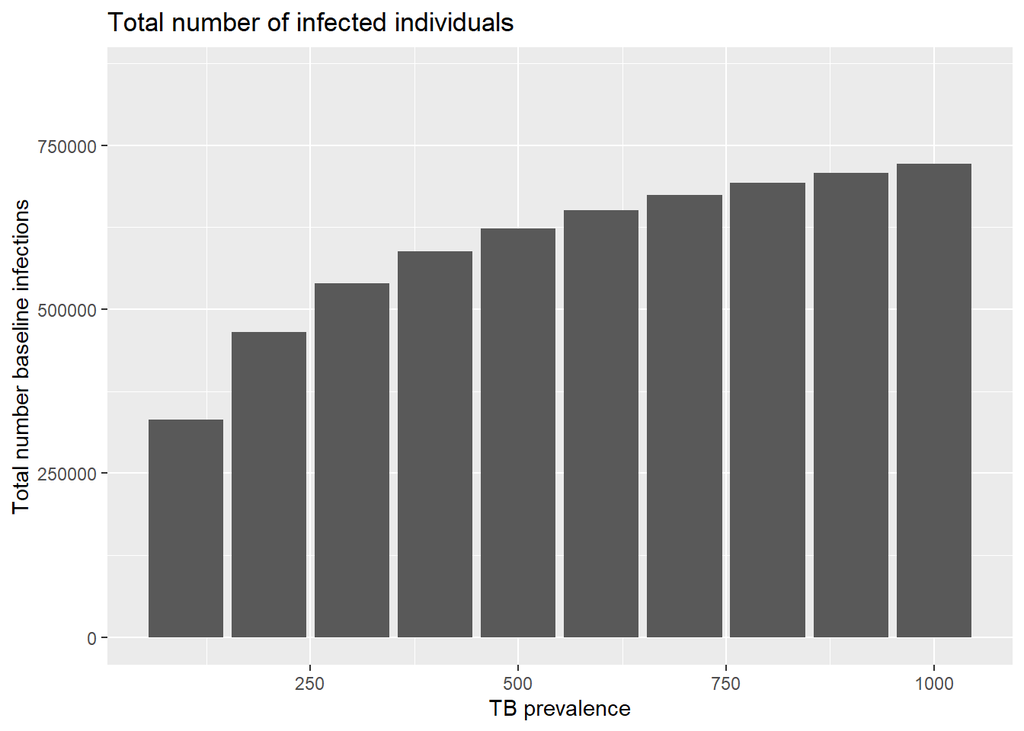

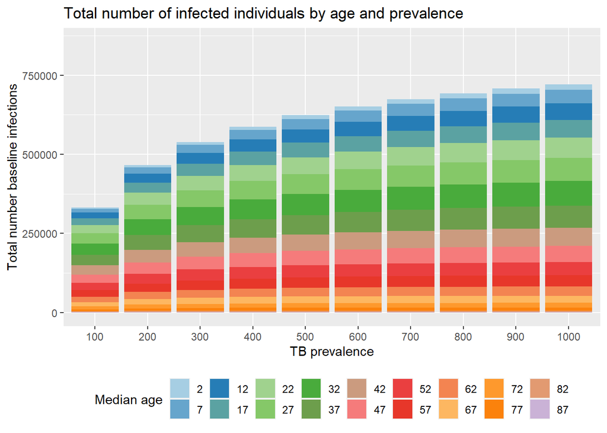

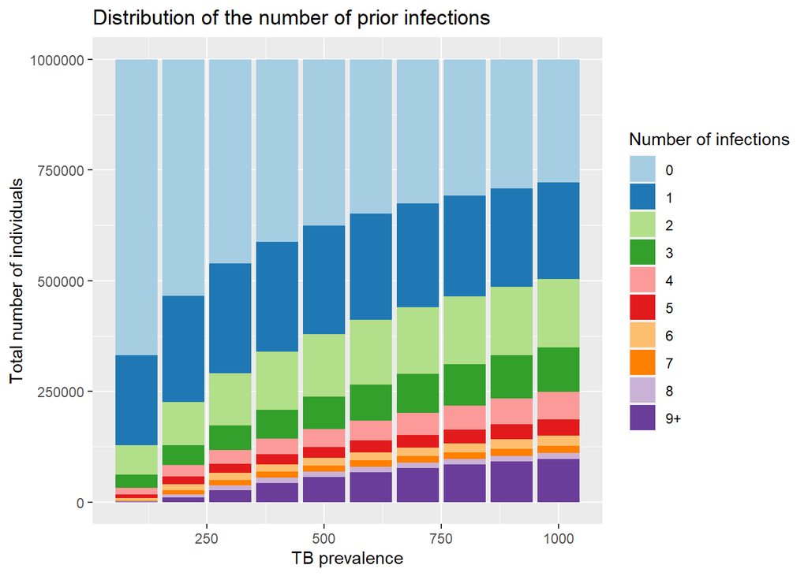

We focus in on those with at least six prior infections in this plot.

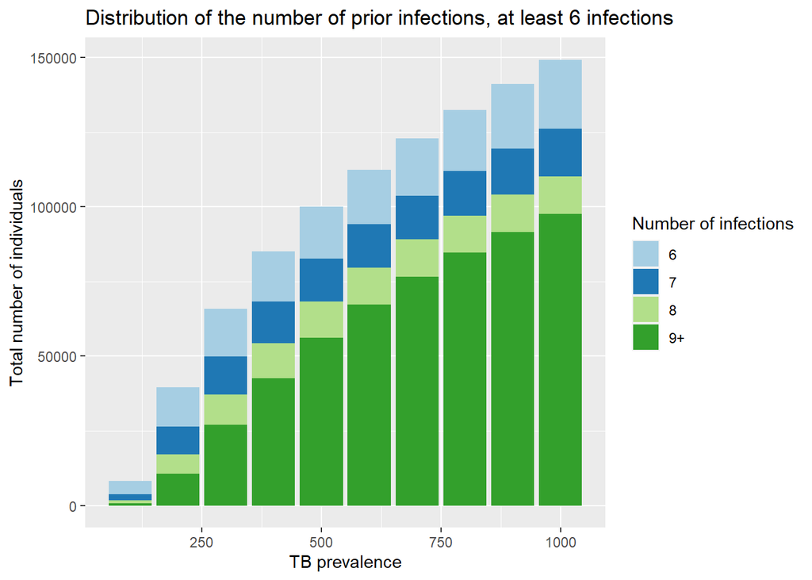

We show the prevalence of LTBI by age and TB disease prevlance. This can be compared to the Dodd et al data.

Prevalence of LTBI by age and TB prevalence

|  | Prev100 | Prev200 | Prev300 | Prev400 | Prev500 | Prev600 | Prev700 | Prev800 | Prev900 | Prev1000 |
| --- | --- | --- | --- | --- | --- | --- | --- | --- | --- | --- |
| 0-4 | 0.04 | 0.07 | 0.09 | 0.11 | 0.12 | 0.14 | 0.15 | 0.16 | 0.17 | 0.18 |
| 5-9 | 0.12 | 0.21 | 0.26 | 0.30 | 0.33 | 0.35 | 0.38 | 0.40 | 0.41 | 0.43 |
| 10-14 | 0.20 | 0.31 | 0.37 | 0.42 | 0.46 | 0.49 | 0.52 | 0.54 | 0.56 | 0.57 |
| 15-19 | 0.26 | 0.39 | 0.46 | 0.51 | 0.55 | 0.59 | 0.61 | 0.64 | 0.66 | 0.68 |
| 20-24 | 0.31 | 0.45 | 0.53 | 0.59 | 0.63 | 0.66 | 0.69 | 0.71 | 0.73 | 0.75 |
| 25-29 | 0.35 | 0.50 | 0.59 | 0.65 | 0.69 | 0.72 | 0.75 | 0.77 | 0.79 | 0.81 |
| 30-34 | 0.39 | 0.55 | 0.64 | 0.70 | 0.74 | 0.77 | 0.80 | 0.82 | 0.84 | 0.86 |
| 35-39 | 0.43 | 0.59 | 0.68 | 0.74 | 0.78 | 0.81 | 0.84 | 0.86 | 0.88 | 0.89 |
| 40-44 | 0.46 | 0.63 | 0.72 | 0.78 | 0.82 | 0.85 | 0.87 | 0.89 | 0.90 | 0.92 |
| 45-49 | 0.49 | 0.66 | 0.75 | 0.81 | 0.85 | 0.87 | 0.90 | 0.91 | 0.92 | 0.93 |
| 50-54 | 0.52 | 0.69 | 0.78 | 0.83 | 0.87 | 0.90 | 0.92 | 0.93 | 0.94 | 0.95 |
| 55-59 | 0.55 | 0.72 | 0.81 | 0.86 | 0.89 | 0.92 | 0.93 | 0.94 | 0.95 | 0.96 |
| 60-64 | 0.57 | 0.75 | 0.83 | 0.88 | 0.91 | 0.93 | 0.95 | 0.96 | 0.96 | 0.97 |
| 65=-69 | 0.59 | 0.77 | 0.85 | 0.90 | 0.92 | 0.94 | 0.96 | 0.97 | 0.97 | 0.98 |
| 70-74 | 0.61 | 0.79 | 0.87 | 0.91 | 0.94 | 0.95 | 0.96 | 0.97 | 0.98 | 0.98 |
| 75-79 | 0.63 | 0.81 | 0.88 | 0.92 | 0.95 | 0.96 | 0.97 | 0.98 | 0.98 | 0.99 |
| 80-84 | 0.65 | 0.82 | 0.90 | 0.93 | 0.96 | 0.97 | 0.98 | 0.98 | 0.99 | 0.99 |
| 85+ | 0.67 | 0.84 | 0.91 | 0.94 | 0.96 | 0.97 | 0.98 | 0.99 | 0.99 | 0.99 |

We also show the total number of infections and total number of times individuals have been infected by risk category.

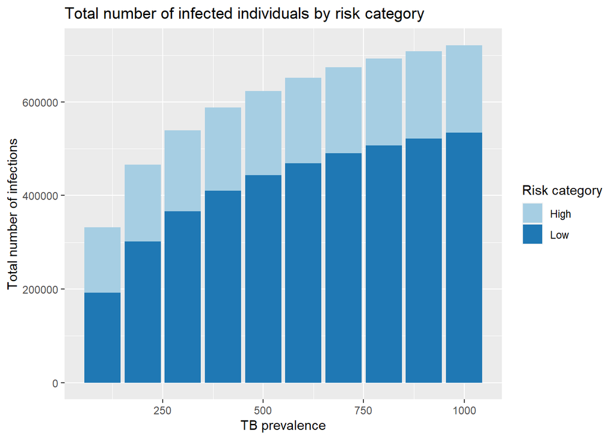

We can also consider the number of infections individuals have by prevalence and risk category.

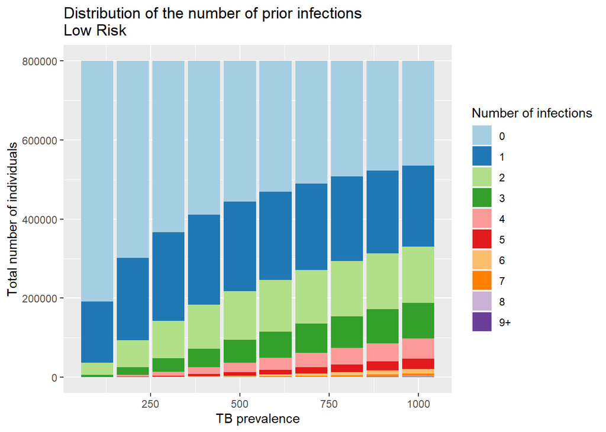

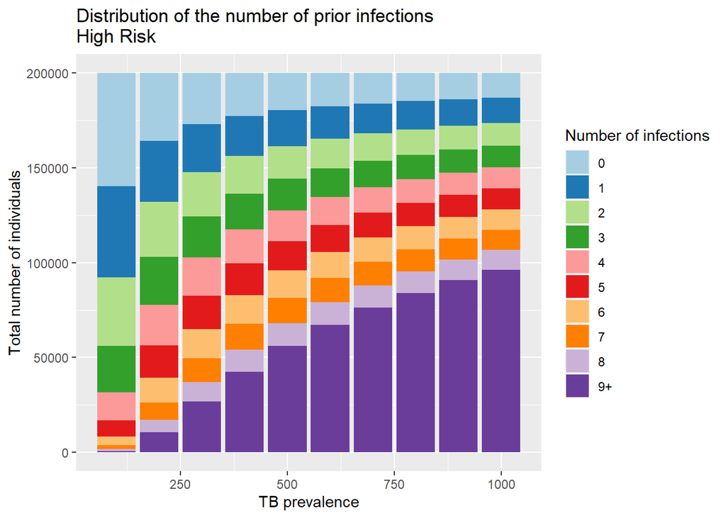

## New cases generated over one year

We now generate cases over a one year period. All infected individuals with no reinfection in this year have a 0.00075 probability of progressing to active disease. Individuals with a first infection have a 0.04 probability of progressing. Those with a new re-infection follow the probability of progressing determined by Ackley.

[output not shown]

[output not shown]

[output not shown]

[output not shown]

[output not shown]

[output not shown]

[output not shown]

We can calculate the following statistics (the first 6 only apply to the mixing scenarios):

- Cases from first infection, low risk
- Cases from reinfection, low risk
- Total cases, low risk
- Cases from first infection, high risk
- Cases from reinfection, high risk
- Total cases, high risk
- Cases from old infection (all in high risk)
- Total cases
- percent cases from first infection
- percent cases from old infection
- Corrected prevalence (=1.66*smear positive prevalence)
- Incidence (per 100000)
- Implied duration (=prev/Inc)
- Reproductive number for infection (= #new infections/corrected prevalence)
- Reproductive number for disease (= #ATB from new infections/corrected prevalence)

### Dodd, homogeneous risk

| ATB from old infections | Total ATB | percent first inf | percent old inf | corrected prevalence | incidence (per 100,000) | duration | Rt infections | Rt disease |
| --- | --- | --- | --- | --- | --- | --- | --- | --- |
| 185.0388 | 1303.992 | 0.6772338 | 0.1419018 | 1660 | 130.3992 | 12.730144 | 19.55717 | 0.6740680 |
| 233.0255 | 1322.555 | 0.5958789 | 0.1761934 | 1660 | 132.2555 | 12.551460 | 19.55717 | 0.6563433 |
| 286.2748 | 1351.745 | 0.5053042 | 0.2117817 | 1660 | 135.1745 | 12.280423 | 19.55717 | 0.6418495 |
| 337.0972 | 1391.212 | 0.4194158 | 0.2423047 | 1660 | 139.1212 | 11.932043 | 19.55717 | 0.6350088 |
| 376.9093 | 1433.217 | 0.3532655 | 0.2629814 | 1660 | 143.3217 | 11.582338 | 19.55717 | 0.6363298 |
| 413.4952 | 1483.826 | 0.2940409 | 0.2786683 | 1660 | 148.3826 | 11.187295 | 19.55717 | 0.6447776 |
| 450.0263 | 1550.458 | 0.2371649 | 0.2902538 | 1660 | 155.0458 | 10.706513 | 19.55717 | 0.6629107 |
| 467.4772 | 1589.938 | 0.2110589 | 0.2940222 | 1660 | 158.9938 | 10.440656 | 19.55717 | 0.6761815 |
| 498.4591 | 1676.754 | 0.1668886 | 0.2972761 | 1660 | 167.6754 | 9.900078 | 19.55717 | 0.7098165 |
| 512.9697 | 1726.952 | 0.1473419 | 0.2970376 | 1660 | 172.6952 | 9.612312 | 19.55717 | 0.7313145 |

### Dodd, heterogeneous risk

| low risk: ATB from first inf | low risk: ATB from reinfection | low risk: total ATB | high risk: ATB from first int | high risk: ATB from reinfection | high risk: total ATB | ATB from old infections | Total ATB | percent first inf | percent old inf | corrected prevalence | incidence (per 100,000) | duration | Rt infections | Rt disease |
| --- | --- | --- | --- | --- | --- | --- | --- | --- | --- | --- | --- | --- | --- | --- |
| 157.9798 | 14.67455 | 172.6543 | 129.1885 | 129.6439 | 258.8324 | 81.15968 | 512.6464 | 0.5601682 | 0.1583151 | 166 | 51.26464 | 3.238099 | 74.21687 | 2.599318 |
| 207.6747 | 28.03460 | 235.7093 | 138.3951 | 197.4605 | 335.8556 | 89.12620 | 660.6911 | 0.5237997 | 0.1348984 | 332 | 66.06911 | 5.025041 | 48.67470 | 1.721581 |
| 258.5243 | 48.70811 | 307.2324 | 146.9673 | 322.1475 | 469.1147 | 97.02570 | 873.3728 | 0.4642823 | 0.1110931 | 498 | 87.33728 | 5.702032 | 42.81124 | 1.558930 |
| 303.9625 | 75.52774 | 379.4902 | 153.0513 | 509.4023 | 662.4536 | 102.59196 | 1144.5358 | 0.3993006 | 0.0896363 | 664 | 114.45358 | 5.801479 | 40.96385 | 1.569192 |
| 343.1123 | 107.54092 | 450.6532 | 156.6236 | 716.7150 | 873.3386 | 105.39557 | 1429.3874 | 0.3496154 | 0.0737348 | 830 | 142.93874 | 5.806683 | 39.51807 | 1.595171 |
| 380.2819 | 148.75207 | 529.0340 | 159.4069 | 984.5509 | 1143.9578 | 106.90402 | 1779.8957 | 0.3032137 | 0.0600620 | 996 | 177.98957 | 5.595833 | 39.15663 | 1.679711 |
| 418.5149 | 207.15715 | 625.6720 | 161.8904 | 1371.2313 | 1533.1216 | 107.31825 | 2266.1119 | 0.2561238 | 0.0473579 | 1162 | 226.61119 | 5.127726 | 40.13769 | 1.857826 |
| 436.7345 | 243.02253 | 679.7570 | 162.9855 | 1616.8889 | 1779.8744 | 107.07628 | 2566.7077 | 0.2336534 | 0.0417174 | 1328 | 256.67077 | 5.173943 | 38.34337 | 1.852132 |
| 470.7120 | 330.18601 | 800.8980 | 164.7491 | 2189.5884 | 2354.3375 | 105.83863 | 3261.0741 | 0.1948625 | 0.0324551 | 1494 | 326.10741 | 4.581313 | 40.16064 | 2.111938 |
| 486.8873 | 384.53323 | 871.4205 | 165.4856 | 2544.1917 | 2709.6774 | 104.83792 | 3685.9358 | 0.1769898 | 0.0284427 | 1660 | 368.59358 | 4.503605 | 39.20482 | 2.157288 |

### Parameter sweep, homogeneous risk

| ATB from old infections | Total ATB | percent first inf | percent old inf | corrected prevalence | incidence (per 100,000) | duration | Rt infections | Rt disease |
| --- | --- | --- | --- | --- | --- | --- | --- | --- |
| 252.6014 | 831.730 | 0.5252876 | 0.3037060 | 1660 | 83.1730 | 19.958399 | 10.18072 | 0.3488727 |
| 401.0071 | 1658.959 | 0.3858889 | 0.2417221 | 1660 | 165.8959 | 10.006274 | 22.53012 | 0.7578024 |
| 469.1098 | 2489.712 | 0.2882579 | 0.1884193 | 1660 | 248.9712 | 6.667438 | 33.97590 | 1.2172303 |
| 501.4334 | 3318.569 | 0.2267133 | 0.1510993 | 1660 | 331.8569 | 5.002156 | 43.79518 | 1.6970698 |
| 518.4234 | 4152.410 | 0.1858572 | 0.1248488 | 1660 | 415.2410 | 3.997679 | 52.40964 | 2.1891484 |
| 527.7355 | 4982.627 | 0.1573970 | 0.1059151 | 1660 | 498.2627 | 3.331576 | 60.06024 | 2.6836695 |
| 532.8604 | 5809.636 | 0.1365258 | 0.0917201 | 1660 | 580.9636 | 2.857322 | 66.98795 | 3.1787807 |
| 535.5005 | 6636.418 | 0.1205438 | 0.0806912 | 1660 | 663.6418 | 2.501349 | 73.37349 | 3.6752512 |
| 536.5615 | 7473.748 | 0.1077746 | 0.0717928 | 1660 | 747.3748 | 2.221108 | 79.39759 | 4.1790281 |
| 536.5449 | 8302.797 | 0.0975517 | 0.0646222 | 1660 | 830.2797 | 1.999326 | 85.00000 | 4.6784651 |

### Parameter sweep, heterogeneous risk

| low risk: ATB from first inf | low risk: ATB from reinfection | low risk: total ATB | high risk: ATB from first int | high risk: ATB from reinfection | high risk: total ATB | ATB from old infections | Total ATB | percent first inf | percent old inf | corrected prevalence | incidence (per 100,000) | duration | Rt infections | Rt disease |
| --- | --- | --- | --- | --- | --- | --- | --- | --- | --- | --- | --- | --- | --- | --- |
| 246.9583 | 43.25451 | 290.2128 | 145.8346 | 299.488 | 445.3226 | 95.96519 | 831.5005 | 0.4723904 | 0.1154121 | 166 | 83.15005 | 1.996391 | 122.28916 | 4.430936 |
| 368.9345 | 134.81245 | 503.7469 | 158.6050 | 893.763 | 1052.3680 | 106.55861 | 1662.6735 | 0.3172839 | 0.0640887 | 332 | 166.26735 | 1.996784 | 111.44578 | 4.687093 |
| 432.9871 | 235.12641 | 668.1135 | 162.7247 | 1552.677 | 1715.4019 | 107.16364 | 2490.6790 | 0.2391765 | 0.0430259 | 498 | 249.06790 | 1.999455 | 100.20080 | 4.786175 |
| 473.0053 | 337.29112 | 810.2965 | 164.8618 | 2237.666 | 2402.5280 | 105.70994 | 3318.5343 | 0.1922135 | 0.0318544 | 664 | 331.85343 | 2.000883 | 91.41566 | 4.838591 |
| 500.7182 | 440.16548 | 940.8837 | 166.0948 | 2940.581 | 3106.6759 | 103.62236 | 4151.1820 | 0.1606321 | 0.0249621 | 830 | 415.11820 | 1.999431 | 84.57831 | 4.876578 |
| 520.9555 | 542.18478 | 1063.1403 | 166.7845 | 3649.117 | 3815.9010 | 101.33973 | 4980.3811 | 0.1380898 | 0.0203478 | 996 | 498.03811 | 1.999847 | 79.01606 | 4.898636 |
| 536.5213 | 643.89479 | 1180.4161 | 167.1186 | 4365.446 | 4532.5646 | 98.99996 | 5811.9807 | 0.1210671 | 0.0170338 | 1162 | 581.19807 | 1.999318 | 74.44062 | 4.916507 |
| 548.8128 | 744.53609 | 1293.3489 | 167.1983 | 5082.854 | 5250.0518 | 96.68250 | 6640.0832 | 0.1078316 | 0.0145604 | 1328 | 664.00832 | 1.999975 | 70.55723 | 4.927260 |
| 558.9035 | 845.46256 | 1404.3661 | 167.0883 | 5809.923 | 5977.0117 | 94.38394 | 7475.7617 | 0.0971128 | 0.0126253 | 1494 | 747.57617 | 1.998459 | 67.26908 | 4.940681 |
| 567.1431 | 944.01052 | 1511.1536 | 166.8368 | 6526.457 | 6693.2936 | 92.17661 | 8296.6239 | 0.0884673 | 0.0111101 | 1660 | 829.66239 | 2.000814 | 64.33735 | 4.942438 |

### Plotting the results

We show the number of TB disease cases by prevalence and source (old infection, new primary infection, re-infection).

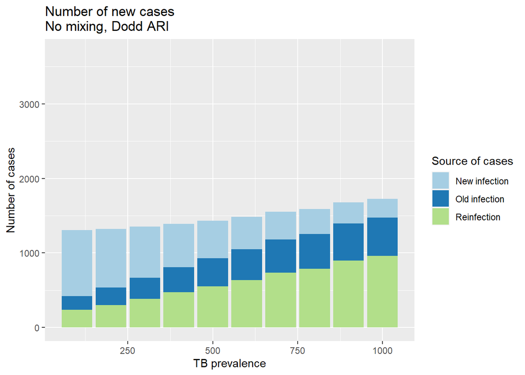

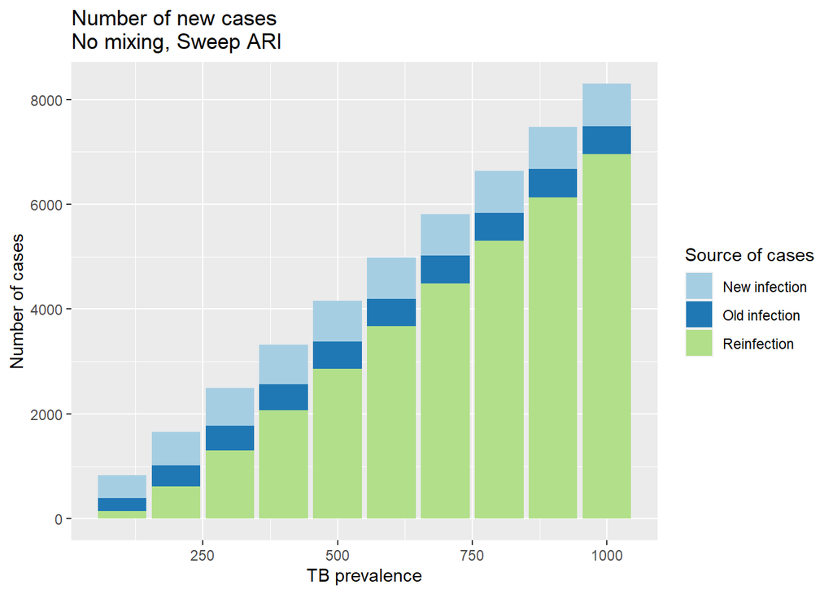

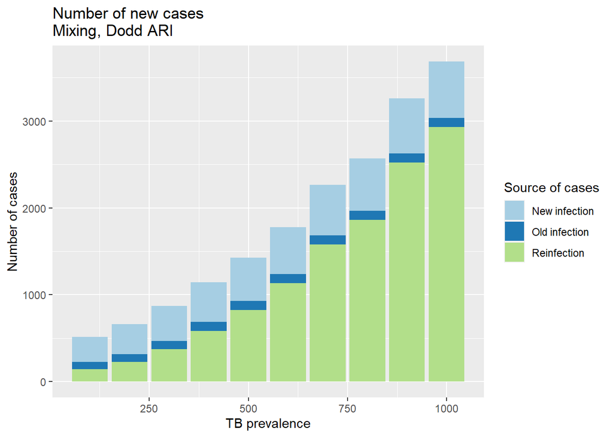

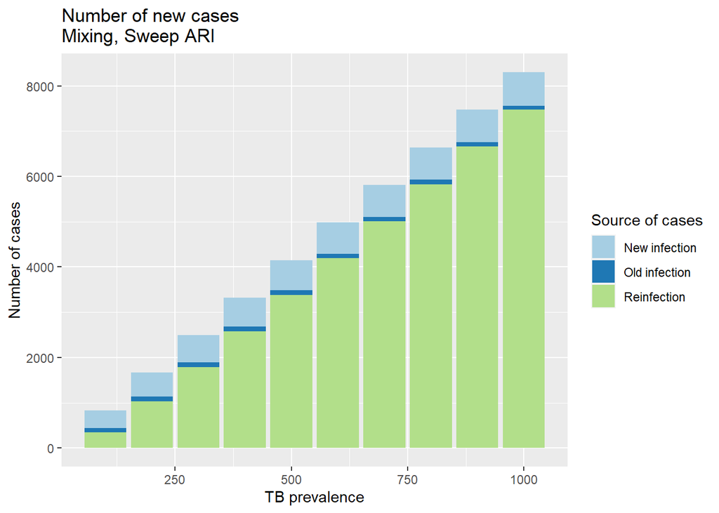